# flight-delays

**Flight Delays Predictive Model:**

```python
import pandas as pd
import matplotlib.pyplot as plt
import numpy as np
from sklearn.metrics import classification_report

np.random.seed(7)
```

```
1.0    1013845
0.0    1013845
Name: DEP_DEL15, dtype: int64
```

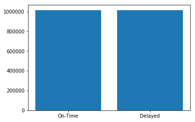

```python
balanced_data = pd.read_csv('2017_2M_balanced.csv')
print balanced_data.DEP_DEL15.value_counts()
plt.bar([0, 1], balanced_data.DEP_DEL15.value_counts(), tick_label=[0, 1])
plt.xticks([0, 1], ['On-Time', 'Delayed'])
plt.show()
```

As we can see the data is split 50/50 between delayed and on-time. This was achieved by collecting all data from 2017 which was about 5M records 4M on-time and 1m delayed. All delayed records were taken on just 1M from the 5M on-time fligths.

Now we have a dataset of ~2M records with a perfect split 50/50. This will be very good for our modeling algorithms.

**Data Cleansing:**

```python
columns = ['level_0', 'index', 'Unnamed: 24', 'FL_DATE', 'FL_NUM', 'CARRIER', 'AIRLINE_ID', u'ORIGIN_AIRPORT_ID',
           u'ORIGIN_WAC', u'DEST_AIRPORT_ID', u'DEST_WAC', u'DEP_DELAY']
balanced_data.columns.tolist()
```

```
['YEAR',
 'QUARTER',
 'MONTH',
 'DAY_OF_MONTH',
 'DAY_OF_WEEK',
 'FL_DATE',
 'UNIQUE_CARRIER',
 'AIRLINE_ID',
 'CARRIER',
 'FL_NUM',
 'ORIGIN_AIRPORT_ID',
 'ORIGIN',
 'ORIGIN_CITY_NAME',
 'ORIGIN_WAC',
 'DEST_AIRPORT_ID',
 'DEST',
 'DEST_CITY_NAME',
 'DEST_WAC',
 'DEP_TIME',
 'DEP_DELAY',
 'DEP_DEL15',
 'ARR_TIME',
 'AIR_TIME',
 'DISTANCE']
```

We want to remove some columns as they are either redundant (ORIGIN_AIRPORT_ID, ORIGIN) or they would give the models a way to cheat (DEP_DELAY: gives how many minutes the flight was delight, ARR_TIME: actual arrival time).

```python
drop = ['FL_NUM', 'FL_DATE', 'AIRLINE_ID', 'ORIGIN_AIRPORT_ID', 'ORIGIN_WAC', 'DEST_AIRPORT_ID',
        'DEST_WAC', 'DEP_DELAY', 'ARR_TIME', 'CARRIER']
balanced_data = balanced_data.drop(drop, 1)

# for c in balanced_data.columns:
#     # convert non continuout data to category, this makes it easier for pd.get_dummies
#     if c in : continue
#     balanced_data[c] = balanced_data[c].astype('category')
```

```python
print balanced_data.isna().sum()
print 'Percentage of rows with missing data: %.2f%%' % (balanced_data.isna().sum().values.sum()*100.0/len(balanced_data))
```

```
YEAR                   0
QUARTER                0
MONTH                  0
DAY_OF_MONTH           0
DAY_OF_WEEK            0
UNIQUE_CARRIER         0
ORIGIN                 0
ORIGIN_CITY_NAME       0
DEST                   0
DEST_CITY_NAME         0
DEP_TIME               0
DEP_DEL15              0
AIR_TIME            7366
DISTANCE               0
dtype: int64
Percentage of rows with missing data: 0.36%
```

The 'AIR_TIME' columns is missing some data. There are several ways to deal with this:

- removal
- average of all column
- average of all flights between same points
- calcaulating the time throught DISTANCE / SPEED. We have the distance and would take the speed as the average of all other records' AIR_TIME/DISTANCE

You're always advised against removal, however when you have the luxury we have here i.e. large amount of data and very fraction is missing and better to just remove and not waste time at this step.

**We attempted to recover some of the missing data by method 3 below, but it took too long time and we had to stop it, but you can see that we were able to recover ~100 records but it's not worth it.**

```python
na = balanced_data.AIR_TIME.isna()
indices = na[na].index
for ind in indices:
    origin, dest = balanced_data.loc[ind, ['ORIGIN', 'DEST']].values
    matches = balanced_data[(balanced_data.ORIGIN == origin) & (balanced_data.DEST == dest)].AIR_TIME.values
    good_matches = ~np.isnan(matches)
    avg = np.average(matches[good_matches])
    balanced_data.at[ind, 'AIR_TIME'] = avg
```

```python
print balanced_data.isna().sum()
print 'Percentage of rows with missing data: %.2f%%' % (balanced_data.isna().sum().values.sum()*100.0/len(balanced_data))
```

```
YEAR                   0
QUARTER                0
MONTH                  0
DAY_OF_MONTH           0
DAY_OF_WEEK            0
UNIQUE_CARRIER         0
ORIGIN                 0
ORIGIN_CITY_NAME       0
DEST                   0
DEST_CITY_NAME         0
DEP_TIME               0
DEP_DEL15              0
AIR_TIME            7227
DISTANCE               0
dtype: int64
Percentage of rows with missing data: 0.36%
```

```python
balanced_data = balanced_data.dropna(axis=0)
print balanced_data.isna().sum()
print '\nPercentage of rows with missing data: %.2f%%' % (balanced_data.isna().sum().values.sum()*100.0/len(balanced_data))
print 'Data shape:', balanced_data.shape
```

```
YEAR                0
QUARTER             0
MONTH               0
DAY_OF_MONTH        0
DAY_OF_WEEK         0
UNIQUE_CARRIER      0
ORIGIN              0
ORIGIN_CITY_NAME    0
DEST                0
DEST_CITY_NAME      0
DEP_TIME            0
DEP_DEL15           0
AIR_TIME            0
DISTANCE            0
dtype: int64

Percentage of rows with missing data: 0.00%
Data shape: (2020463, 14)
```

**One Hot Encoding Categorical values:**

```python
categorical_columns = list(set(balanced_data.columns).difference(set(['YEAR', 'DEP_TIME', 'ARR_TIME', 'AIR_TIME', 'DISTANCE', 'DEP_DEL15'])))
training_data_onehotencoded = pd.get_dummies(balanced_data, columns=categorical_columns)
```

```python
training_data_onehotencoded.shape
```

```
(2020463, 1337)
```

Let's start by features and analyze our original features we had.

```python
unique_origin_cities = balanced_data.ORIGIN_CITY_NAME.value_counts()
unique_dest_cities = balanced_data.DEST_CITY_NAME.value_counts()
len(unique_origin_cities), len(unique_dest_cities)
```

```
(315, 314)
```

A lot of cities. We don't need all that let's take only include the top 15 city (in terms of number of flights).

```python
unique_origin_city_names = balanced_data.ORIGIN_CITY_NAME.value_counts()[:15].index
unique_dest_city_names = balanced_data.DEST_CITY_NAME.value_counts()[:15].index
reduced_data = balanced_data[balanced_data.ORIGIN_CITY_NAME.isin(unique_origin_city_names) & \
                balanced_data.DEST_CITY_NAME.isin(unique_dest_city_names)]

training_data_onehotencoded = pd.get_dummies(reduced_data, columns=categorical_columns)
training_data_onehotencoded.shape
```

```
(431129, 136)
```

Okay now this is much better, as we can see the number of records (rows) decreased as well to 430K.

**Training a base line model:**

Let's just quickly train a model with no tweaks or further enhancements to the dataset. We do this to get a feel of how a predictive model would perform on such a task and to see how relevant our change are.

We'll use a RandomForest for this because they're fast and easy to setup. Since we have a lot of data, we can split 50/50 train and test to speed up the training process. (usually you want to go for 80/20, 70/30)

```python
from sklearn.ensemble import RandomForestClassifier
from sklearn.cross_validation import train_test_split
from sklearn.metrics import classification_report

X = training_data_onehotencoded.drop(['DEP_DEL15'], 1)
Y = training_data_onehotencoded.DEP_DEL15
x_train, x_test, y_train, y_test = train_test_split(X, Y, test_size=0.5, random_state=0)
```

```python
classifier = RandomForestClassifier(n_estimators = 100, criterion='gini', max_features='auto', oob_score=True, n_jobs=2, random_state=50)
calssifier = classifier.fit(x_train,y_train)
```

```python
predictions = calssifier.predict(x_test)
print(classification_report(y_test, predictions,target_names=['On-Time', 'Delayed']))
```

```
             precision    recall  f1-score   support

    On-Time       0.71      0.69      0.70     98690
    Delayed       0.75      0.76      0.75    116875

avg / total       0.73      0.73      0.73    215565
```

Okay so the first result we got is **~70% Accuracy**, that's not bad to start with.

**Note** that for this problem, 'accuracy' metric is not enough. The more interesting metric is the 'recall' of the Delayed flights. This is because people are interested in how accurate are you when you tell them their flight is going to be delayed (no one is interested in knowing it's gonna be on time!).

Recall for Delayed means the following: out of all the actually delayed flights, how many was the model able to predict. Here the model was able to predict 76% of them meaning when the model tells you your flight is delayed, there is a 76% chance it's correct.

**Overall Accuracy: 73%**

**Delayed Recall: 76%**

**More Preprocessing:**

Let's take another look at the columns we had

```python
balanced_data.columns.values
```

```
array(['YEAR', 'QUARTER', 'MONTH', 'DAY_OF_MONTH', 'DAY_OF_WEEK',
       'UNIQUE_CARRIER', 'ORIGIN', 'ORIGIN_CITY_NAME', 'DEST',
       'DEST_CITY_NAME', 'DEP_TIME', 'DEP_DEL15', 'AIR_TIME', 'DISTANCE'], dtype=object)
```

- 'YEAR' is useless because the dataset is for 2017 only.
- The info in 'QUARTER' is kind of encoded in the 'MONTH'.
- It's better to just work by Airport for origin and destincation since there could be a correlation, where certain airports are more likely to delay flights when they don't have the capacity.
- 'DEP_TIME' is the local time the flight was scheduled, let's take a look on how it's formatted.

```python
balanced_data.DEP_TIME.value_counts().index.sort_values()
```

```
Float64Index([   1.0,    2.0,    3.0,    4.0,    5.0,    6.0,    7.0,    8.0,
                 9.0,   10.0,
              ...
              2351.0, 2352.0, 2353.0, 2354.0, 2355.0, 2356.0, 2357.0, 2358.0,
              2359.0, 2400.0],
             dtype='float64', length=1440)
```

so it's 24-hour encoded as a number 0001-2400 == (1 min past midnight - midnight). Any model will treat this as a number and no pattern will be discovered e.g. flights in the early morning or the afternoon see more delays, or if there are some flights rush-hours like you have with car traffic.

What we're going to do is to split the day into 8 segments 3 hours each, those 8 segments will be added as features and 1 of them will have a value of 1 for each row depending on the time of the flight.

```python
preprocessed_data = reduced_data
preprocessed_data['TIME_0_3'] = ((preprocessed_data.DEP_TIME > 0) & (preprocessed_data.DEP_TIME <= 300)).astype(int)
preprocessed_data['TIME_3_6'] = ((preprocessed_data.DEP_TIME > 300) & (preprocessed_data.DEP_TIME <= 600)).astype(int)
preprocessed_data['TIME_6_9'] = ((preprocessed_data.DEP_TIME > 600) & (preprocessed_data.DEP_TIME <= 900)).astype(int)
preprocessed_data['TIME_9_12'] = ((preprocessed_data.DEP_TIME > 900) & (preprocessed_data.DEP_TIME <= 1200)).astype(int)
preprocessed_data['TIME_12_15'] = ((preprocessed_data.DEP_TIME > 1200) & (preprocessed_data.DEP_TIME <= 1500)).astype(int)
preprocessed_data['TIME_15_18'] = ((preprocessed_data.DEP_TIME > 1500) & (preprocessed_data.DEP_TIME <= 1500)).astype(int)
preprocessed_data['TIME_18_21'] = ((preprocessed_data.DEP_TIME > 1800) & (preprocessed_data.DEP_TIME <= 1800)).astype(int)
preprocessed_data['TIME_21_24'] = ((preprocessed_data.DEP_TIME > 2100) & (preprocessed_data.DEP_TIME <= 2400)).astype(int)
```

For this task a very obvious and valid hypothesis is that delays have a strong correlation with weather status. When there's a storm, heavy rains and crosswind are common causes of flight delays. If we had the weather data, our models will be able to find these patterns and better give a prediction of a flight status.

#### reading data with weather:

```python
data_plus_weather = pd.read_csv('2017_preprocessed_with_weather.csv')
```

```python
data_plus_weather.columns
```

```
Index([u'YEAR', u'QUARTER', u'MONTH', u'DAY_OF_MONTH', u'DAY_OF_WEEK',
       u'UNIQUE_CARRIER', u'ORIGIN', u'ORIGIN_CITY_NAME', u'DEST',
       u'DEST_CITY_NAME', u'DEP_TIME', u'DEP_DEL15', u'AIR_TIME', u'DISTANCE',
       u'TIME_0_3', u'TIME_3_6', u'TIME_6_9', u'TIME_9_12', u'TIME_12_15',
       u'TIME_15_18', u'TIME_18_21', u'TIME_21_24', u'Temp_ORIGIN',
       u'Humidity_ORIGIN', u'Pressure_ORIGIN', u'Windspeed_ORIGIN',
       u'Visibility_ORIGIN', u'Windbearing_ORIGIN', u'Temp_DEST',
       u'Humidity_DEST', u'Pressure_DEST', u'Windspeed_DEST',
       u'Visibility_DEST', u'Windbearing_DEST'],
      dtype='object')
```

now let's delete some of those features we mentioned before.

```python
data_weather = data_plus_weather.drop(['YEAR', 'QUARTER', 'ORIGIN_CITY_NAME', 'DEP_TIME', 'DEST_CITY_NAME'], 1)
```

```python
data_weather.columns, data_weather.shape
```

```
(Index([u'MONTH', u'DAY_OF_MONTH', u'DAY_OF_WEEK', u'UNIQUE_CARRIER', u'ORIGIN',
        u'DEST', u'DEP_DEL15', u'AIR_TIME', u'DISTANCE', u'TIME_0_3',
        u'TIME_3_6', u'TIME_6_9', u'TIME_9_12', u'TIME_12_15', u'TIME_15_18',
        u'TIME_18_21', u'TIME_21_24', u'Temp_ORIGIN', u'Humidity_ORIGIN',
        u'Pressure_ORIGIN', u'Windspeed_ORIGIN', u'Visibility_ORIGIN',
        u'Windbearing_ORIGIN', u'Temp_DEST', u'Humidity_DEST', u'Pressure_DEST',
        u'Windspeed_DEST', u'Visibility_DEST', u'Windbearing_DEST'],
       dtype='object'), (431221, 29))
```

```python
continuous_cols = ['DEP_DEL15', 'DISTANCE', 'AIR_TIME', 'DISTANCE',
                  'Temp_ORIGIN', 'Humidity_ORIGIN', 'Pressure_ORIGIN', 'Windspeed_ORIGIN', 'Visibility_ORIGIN',
                  'Windbearing_ORIGIN', u'Temp_DEST', u'Humidity_DEST', u'Pressure_DEST',
                    u'Windspeed_DEST', u'Visibility_DEST', u'Windbearing_DEST',
                  u'TIME_0_3', u'TIME_3_6', u'TIME_6_9', u'TIME_9_12', u'TIME_12_15',
       u'TIME_15_18', u'TIME_18_21', u'TIME_21_24']
# data_weather.loc[:, continuous_cols]
categorical_columns = list(set(data_weather.columns).difference(set(continuous_cols)))
data_weather = pd.get_dummies(data_weather, columns=categorical_columns)
```

```python
data_weather.shape
```

```
(431221, 120)
```

```python
data_weather = data_weather.dropna(axis=0)
```

```python
data_weather.columns.values
```

```
array(['DEP_DEL15', 'AIR_TIME', 'DISTANCE', 'TIME_0_3', 'TIME_3_6',
       'TIME_6_9', 'TIME_9_12', 'TIME_12_15', 'TIME_15_18', 'TIME_18_21',
       'TIME_21_24', 'Temp_ORIGIN', 'Humidity_ORIGIN', 'Pressure_ORIGIN',
       'Windspeed_ORIGIN', 'Visibility_ORIGIN', 'Windbearing_ORIGIN',
       'Temp_DEST', 'Humidity_DEST', 'Pressure_DEST', 'Windspeed_DEST',
       'Visibility_DEST', 'Windbearing_DEST', 'ORIGIN_ATL', 'ORIGIN_BOS',
       'ORIGIN_DEN', 'ORIGIN_DFW', 'ORIGIN_EWR', 'ORIGIN_HOU',
       'ORIGIN_IAH', 'ORIGIN_JFK', 'ORIGIN_LAS', 'ORIGIN_LAX',
       'ORIGIN_LGA', 'ORIGIN_MCO', 'ORIGIN_MDW', 'ORIGIN_MSP',
       'ORIGIN_ORD', 'ORIGIN_PHX', 'ORIGIN_SEA', 'ORIGIN_SFO', 'DEST_ATL',
       'DEST_BOS', 'DEST_DEN', 'DEST_DFW', 'DEST_EWR', 'DEST_HOU',
       'DEST_IAH', 'DEST_JFK', 'DEST_LAS', 'DEST_LAX', 'DEST_LGA',
       'DEST_MCO', 'DEST_MDW', 'DEST_MSP', 'DEST_ORD', 'DEST_PHX',
       'DEST_SEA', 'DEST_SFO', 'DAY_OF_MONTH_1', 'DAY_OF_MONTH_2',
       'DAY_OF_MONTH_3', 'DAY_OF_MONTH_4', 'DAY_OF_MONTH_5',
       'DAY_OF_MONTH_6', 'DAY_OF_MONTH_7', 'DAY_OF_MONTH_8',
       'DAY_OF_MONTH_9', 'DAY_OF_MONTH_10', 'DAY_OF_MONTH_11',
       'DAY_OF_MONTH_12', 'DAY_OF_MONTH_13', 'DAY_OF_MONTH_14',
       'DAY_OF_MONTH_15', 'DAY_OF_MONTH_16', 'DAY_OF_MONTH_17',
       'DAY_OF_MONTH_18', 'DAY_OF_MONTH_19', 'DAY_OF_MONTH_20',
       'DAY_OF_MONTH_21', 'DAY_OF_MONTH_22', 'DAY_OF_MONTH_23',
       'DAY_OF_MONTH_24', 'DAY_OF_MONTH_25', 'DAY_OF_MONTH_26',
       'DAY_OF_MONTH_27', 'DAY_OF_MONTH_28', 'DAY_OF_MONTH_29',
       'DAY_OF_MONTH_30', 'DAY_OF_MONTH_31', 'DAY_OF_WEEK_1',
       'DAY_OF_WEEK_2', 'DAY_OF_WEEK_3', 'DAY_OF_WEEK_4', 'DAY_OF_WEEK_5',
       'DAY_OF_WEEK_6', 'DAY_OF_WEEK_7', 'MONTH_1', 'MONTH_2', 'MONTH_3',
       'MONTH_4', 'MONTH_5', 'MONTH_6', 'MONTH_7', 'MONTH_8', 'MONTH_9',
       'MONTH_10', 'MONTH_11', 'MONTH_12', 'UNIQUE_CARRIER_AA',
       'UNIQUE_CARRIER_AS', 'UNIQUE_CARRIER_B6', 'UNIQUE_CARRIER_DL',
       'UNIQUE_CARRIER_EV', 'UNIQUE_CARRIER_F9', 'UNIQUE_CARRIER_NK',
       'UNIQUE_CARRIER_OO', 'UNIQUE_CARRIER_UA', 'UNIQUE_CARRIER_VX',
       'UNIQUE_CARRIER_WN'], dtype=object)
```

Let's normalize the continous columns. It's usually a good idea to normalize since it makes the process of learning easier/faster (models will have a smaller range or space to work within when multiplying and crunching numbers)

We have a lot of data and while this is good for improving the performance of the prediction, it requires more resources and time to train. For that reason we're only going to work with 5% (~20,000 records) of the data.

```python
from sklearn.preprocessing import MinMaxScaler
# data_fraction = training_data_onehotencoded.sample(frac=1)
fraction = data_weather.sample(frac=0.05)
X = fraction.drop(['DEP_DEL15'], 1)
Y = fraction.DEP_DEL15

scaler_X = MinMaxScaler()
scaler_X.fit(X)
X = scaler_X.transform(X)
```

**Comparing ML Models:**

Okay, **FINALLY** we have our data clean and ready with weather data added. Let's now try some ML algorithms and see how they perform.

**Random Forests:**

```python
from sklearn.ensemble import RandomForestClassifier
from sklearn.cross_validation import train_test_split
from sklearn.metrics import classification_report

x_train, x_test, y_train, y_test = train_test_split(X, Y, test_size=0.3, random_state=0)
```

```python
classifier = RandomForestClassifier(n_estimators = 100, oob_score=True, n_jobs=2, random_state=50)
calssifier = classifier.fit(x_train,y_train)
```

```python
y_pred = calssifier.predict(x_test)
print(classification_report(y_test, y_pred,target_names=['On-Time', 'Delayed']))
```

```
             precision    recall  f1-score   support

    On-Time       0.66      0.57      0.61      2969
    Delayed       0.67      0.75      0.71      3491

avg / total       0.67      0.67      0.66      6460
```

**Logistic Regression:**

```python
from sklearn.feature_selection import RFE
from sklearn.linear_model import LogisticRegression

logreg = LogisticRegression()
logreg.fit(x_train, y_train)

from sklearn import model_selection
from sklearn.model_selection import cross_val_score

kfold = model_selection.KFold(n_splits=10, random_state=7)
modelCV = LogisticRegression()
scoring = 'accuracy'
results = model_selection.cross_val_score(modelCV, x_train, y_train, cv=kfold, scoring=scoring)
print("10-fold cross validation average accuracy: %.3f" % (results.mean()))
```

```
10-fold cross validation average accuracy: 0.661
```

```python
y_pred = logreg.predict(x_test)
# Classification Report:
print(classification_report(y_test, y_pred, target_names=['On-Time', 'Delayed']))
```

```
             precision    recall  f1-score   support

    On-Time       0.66      0.55      0.60      2969
    Delayed       0.67      0.76      0.71      3491

avg / total       0.67      0.67      0.66      6460
```

**K-Nearest Neighbour:**

```python
from sklearn.neighbors import KNeighborsClassifier

classifier = KNeighborsClassifier(n_neighbors=8)
# classifier.fit(x_train, y_train)

kfold = model_selection.KFold(n_splits=10, random_state=7)
modelCV = KNeighborsClassifier(n_neighbors=8)
scoring = 'accuracy'
results = model_selection.cross_val_score(modelCV, x_train, y_train, cv=kfold, scoring=scoring)
print("10-fold cross validation average accuracy: %.3f" % (results.mean()))
```

```
10-fold cross validation average accuracy: 0.608
```

```python
classifier.fit(x_train, y_train)
y_pred = classifier.predict(x_test)
# Classification Report:
print(classification_report(y_test, y_pred, target_names=['On-Time', 'Delayed']))
```

```
             precision    recall  f1-score   support

    On-Time       0.58      0.60      0.59      2969
    Delayed       0.65      0.62      0.63      3491

avg / total       0.61      0.61      0.61      6460
```

**Neural Network:**

```python
from keras.models import Sequential
from keras.layers import Dense
from keras.layers import Dropout
from keras.wrappers.scikit_learn import KerasClassifier
from keras.constraints import maxnorm
from keras import optimizers

def create_model(features, architecture=[50]):
    model = Sequential()
    model.add(Dense(100, input_dim=features, activation='relu'))
    for layer_neurons in architecture:
        model.add(Dense(layer_neurons, kernel_initializer='normal', activation='relu'))
    model.add(Dense(1, activation='sigmoid'))
    adam = optimizers.Adam(lr=0.005, decay=0.001)
    model.compile(loss='binary_crossentropy', optimizer='adam', metrics=['accuracy'])
    return model

batch      = 256
epochs     = 100
# array size is number of hidden layers, and numbers are number of neurons in each layer
architecture = [50, 20]
model = create_model(architecture=architecture, features=x_train.shape[1])
model_fit = model.fit(x_train, y_train, epochs=epochs, batch_size=batch, verbose=0, validation_split=0.15)
```

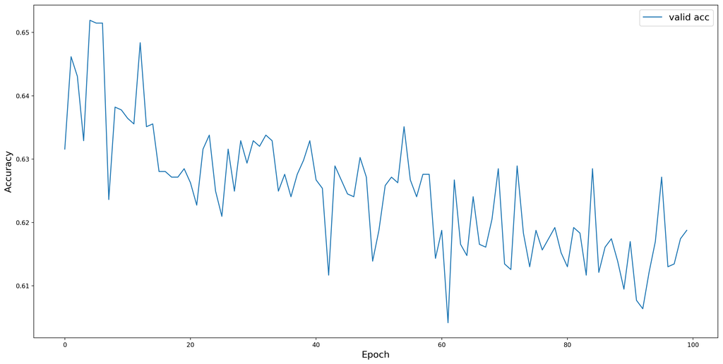

```python
plt.rcParams['figure.figsize'] = (20,10)
plt.rcParams['figure.dpi'] = 200
plt.plot(range(epochs), model_fit.history['val_acc'])
plt.legend(['valid acc'], fontsize=15)
plt.xlabel('Epoch', fontsize=15)
plt.ylabel('Accuracy', fontsize=15)
plt.show()
```

Neural net output from last layer is a value in the range 0-1, so we'll set a threshold and anything less than threshold is considered not delayed and vice versa.

```python
threshold = 0.5
pred = model.predict(x_test)
pred[pred > threshold] = 1
pred[pred < threshold] = 0
print(classification_report(y_test, pred, target_names=['On-Time', 'Delayed']))
```

```
             precision    recall  f1-score   support

    On-Time       0.59      0.57      0.58      2969
    Delayed       0.64      0.66      0.65      3491

avg / total       0.62      0.62      0.62      6460
```

**Results Interpretation:**

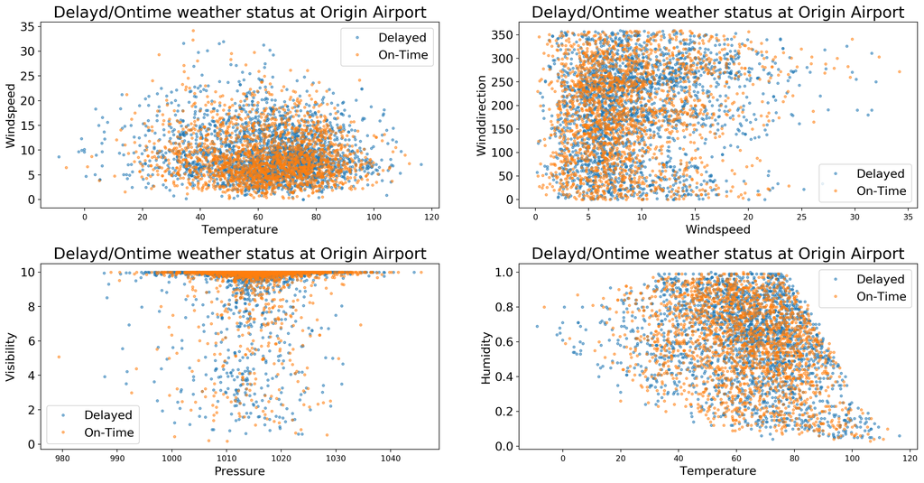

```python
frac = data_plus_weather.sample(frac=0.01)

d = frac[frac.DEP_DEL15 == 1]
plt.subplot(221).plot(d.Temp_ORIGIN, d.Windspeed_ORIGIN, '.', alpha=0.5)
plt.yticks(fontsize=15)

d = frac[frac.DEP_DEL15 == 0]
plt.title('Delayd/Ontime weather status at Origin Airport', fontsize=20)
plt.xlabel('Temperature', fontsize=15)
plt.ylabel('Windspeed', fontsize=15)
plt.subplot(221).plot(d.Temp_ORIGIN, d.Windspeed_ORIGIN, '.', alpha=0.5)
plt.legend(['Delayed', 'On-Time'], fontsize=15)


d = frac[frac.DEP_DEL15 == 1]
plt.subplot(222).plot(d.Windspeed_ORIGIN, d.Windbearing_ORIGIN, '.', alpha=0.5)
plt.yticks(fontsize=15)
d = frac[frac.DEP_DEL15 == 0]
plt.title('Delayd/Ontime weather status at Origin Airport', fontsize=20)
plt.xlabel('Windspeed', fontsize=15)
plt.ylabel('Winddirection', fontsize=15)
plt.subplot(222).plot(d.Windspeed_ORIGIN, d.Windbearing_ORIGIN, '.', alpha=0.5)
plt.legend(['Delayed', 'On-Time'], fontsize=15)


d = frac[frac.DEP_DEL15 == 1]
plt.subplot(223).plot(d.Pressure_ORIGIN, d.Visibility_ORIGIN, '.', alpha=0.5)
plt.yticks(fontsize=15)
d = frac[frac.DEP_DEL15 == 0]
plt.title('Delayd/Ontime weather status at Origin Airport', fontsize=20)
plt.xlabel('Pressure', fontsize=15)
plt.ylabel('Visibility', fontsize=15)
plt.subplot(223).plot(d.Pressure_ORIGIN, d.Visibility_ORIGIN, '.', alpha=0.5)
plt.legend(['Delayed', 'On-Time'], fontsize=15)


d = frac[frac.DEP_DEL15 == 1]
plt.subplot(224).plot(d.Temp_ORIGIN, d.Humidity_ORIGIN, '.', alpha=0.5)
plt.yticks(fontsize=15)
d = frac[frac.DEP_DEL15 == 0]
plt.title('Delayd/Ontime weather status at Origin Airport', fontsize=20)
plt.xlabel('Temperature', fontsize=15)
plt.ylabel('Humidity', fontsize=15)
plt.subplot(224).plot(d.Temp_ORIGIN, d.Humidity_ORIGIN, '.', alpha=0.5)
plt.legend(['Delayed', 'On-Time'], fontsize=15)

plt.subplots_adjust(hspace=0.3)
plt.show()
```

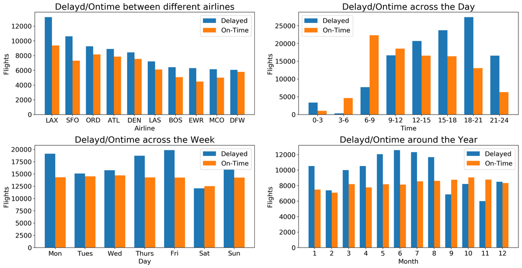

```python
colors=['blue', 'orange']
frac = data_plus_weather.sample(frac=0.5)
frac['TIME_TT'] = (frac.DEP_TIME / 300).astype(int)

d = frac[frac.DEP_DEL15 == 1]
names = d.ORIGIN.value_counts().index.values[:10]
# print d.UNIQUE_CARRIER.value_counts()[names].values
x_axis = np.arange(len(names))
plt.subplot(221).bar(x_axis, d.ORIGIN.value_counts().values[:10], width=0.35)
plt.xticks(x_axis + 0.35/2, d.ORIGIN.value_counts().index, fontsize=15)
plt.yticks(fontsize=15)

d = frac[frac.DEP_DEL15 == 0]
plt.title('Delayd/Ontime between different airlines', fontsize=20)
plt.xlabel('Airline', fontsize=15)
plt.ylabel('Flights', fontsize=15)
plt.subplot(221).bar(0.35+x_axis, d.ORIGIN.value_counts()[names].values, width=0.35)
plt.legend(['Delayed', 'On-Time'], fontsize=15)
# plt.show()



d = frac[frac.DEP_DEL15 == 1]
names = d.TIME_TT.value_counts().index
names = names.sort_values()
x_axis = np.arange(len(names))
plt.subplot(222).bar(x_axis, d.TIME_TT.value_counts()[names].values, width=0.35)

d = frac[frac.DEP_DEL15 == 0]
plt.subplot(222).bar(0.35+x_axis, d.TIME_TT.value_counts()[names].values, width=0.35)

plt.title('Delayd/Ontime across the Day', fontsize=20)
plt.xlabel('Time', fontsize=15)
plt.xticks(x_axis + 0.35/2, ['%d-%d' % (i, i+3) for i in np.arange(0,24,3)], fontsize=15)

plt.ylabel('Flights', fontsize=15)
plt.yticks(fontsize=15)

plt.legend(['Delayed', 'On-Time'], fontsize=15)


d = frac[frac.DEP_DEL15 == 1]
names = d.DAY_OF_WEEK.value_counts().index
names = names.sort_values()
x_axis = np.arange(len(names))
plt.subplot(223).bar(x_axis, d.DAY_OF_WEEK.value_counts()[names].values, width=0.35)

d = frac[frac.DEP_DEL15 == 0]
plt.subplot(223).bar(0.35+x_axis, d.DAY_OF_WEEK.value_counts()[names].values, width=0.35)

plt.title('Delayd/Ontime across the Week', fontsize=20)
plt.xlabel('Day', fontsize=15)
plt.xticks(x_axis + 0.35/2, ['Mon', 'Tues', 'Wed', 'Thurs', 'Fri', 'Sat', 'Sun'], fontsize=15)

plt.ylabel('Flights', fontsize=15)
plt.yticks(fontsize=15)

plt.legend(['Delayed', 'On-Time'], fontsize=15)



d = frac[frac.DEP_DEL15 == 1]
names = d.MONTH.value_counts().index
names = names.sort_values()
x_axis = np.arange(len(names))
plt.subplot(224).bar(x_axis, d.MONTH.value_counts()[names].values, width=0.35)

d = frac[frac.DEP_DEL15 == 0]
plt.subplot(224).bar(0.35+x_axis, d.MONTH.value_counts()[names].values, width=0.35)

plt.title('Delayd/Ontime around the Year', fontsize=20)
plt.xlabel('Month', fontsize=15)
plt.xticks(x_axis + 0.35/2, names, fontsize=15)

plt.ylabel('Flights', fontsize=15)
plt.yticks(fontsize=15)

plt.legend(['Delayed', 'On-Time'], fontsize=15)
plt.subplots_adjust(hspace=0.3)

plt.show()
```

The biggest takeaway from this report is that the quality of data and the features you choose are orders of magnitude more important than the choice of ML model or its parameters. Time should be spent more in the EDA phase deriving as many insights as possible so we can select the better features that will lead to better performance.